# Dataset Overview

#### This data set contains information about 1300 dogs collected from the tweet archive of Twitter user `@dog_rates`, also known as `WeRateDogs` and `The tweet image predictions` which is hosted on Udacity's servers, this data contains:

> tweet_id: is the last part of the tweet URL after "status/" → https://twitter.com/dog_rates/status/889531135344209921

> timestamp: time when tweet is posted

> time_of_day: which part of day when the tweet is posted

> text: the tweet itself

> jpg_url: url of image attached to the tweet

> name: name of the dog

> stage: which breed does the dog belong to, ex:doggo, pup, woof

> dog_breed: which breed does the dog belong to

> img_num: the image number that corresponded to the most confident prediction (numbered 1 to 4 since tweets can have up to four images)

> algorithm_conf: how confident the algorithm is in its prediction

> prediction algorithm: the chosen algorithm

> full_rating: rate of the dog chosen by dog's owner

> rating_numerator: numerator part of the rating

> retweet_count

> favorite_count

```python
df.info()
```

```
<class 'pandas.core.frame.DataFrame'>
RangeIndex: 1304 entries, 0 to 1303
Data columns (total 15 columns):
 #   Column                Non-Null Count  Dtype
---  ------                --------------  -----
 0   tweet_id              1304 non-null   int64
 1   timestamp             1304 non-null   datetime64[ns, UTC]
 2   time_of_day           1304 non-null   category
 3   text                  1304 non-null   object
 4   jpg_url               1304 non-null   object
 5   name                  1304 non-null   object
 6   stage                 1304 non-null   category
 7   dog_breed             1304 non-null   category
 8   img_num               1304 non-null   category
 9   algorithm_conf        1304 non-null   float64
 10  prediction_algorithm  1304 non-null   category
 11  full_rating           1304 non-null   object
 12  rating_numerator      1304 non-null   float64
 13  retweet_count         1304 non-null   int64
 14  favorite_count        1304 non-null   int64
dtypes: category(5), datetime64[ns, UTC](1), float64(2), int64(3), object(4)
memory usage: 114.9+ KB
```

## The Distribution of Breeds of Dogs

- The Data Set contains about 111 Breed of Dogs and it will be too much if we plot all 111 breeds so we will choose the highest 10 breeds and plot them

```python
df.dog_breed.value_counts().to_frame()
```

|  | dog_breed |
| --- | --- |
| golden_retriever | 137 |
| Labrador_retriever | 78 |
| Pembroke | 74 |
| Chihuahua | 68 |
| pug | 45 |
| ... | ... |
| redbone | 1 |
| silky_terrier | 1 |
| standard_schnauzer | 1 |
| toy_terrier | 1 |
| Scotch_terrier | 1 |

111 rows × 1 columns

```python
dog_breed_value_counts = df.dog_breed.value_counts().to_frame()
dog_breed_value_counts.rename(columns={'dog_breed':'value_counts'},inplace=True)
dog_breed_value_counts.index.name='dog_breed'
dog_breed_value_counts.head(10)
```

| dog_breed | value_counts |
| --- | --- |
| golden_retriever | 137 |
| Labrador_retriever | 78 |
| Pembroke | 74 |
| Chihuahua | 68 |
| pug | 45 |
| chow | 40 |
| Samoyed | 39 |
| Pomeranian | 34 |
| toy_poodle | 32 |
| cocker_spaniel | 28 |

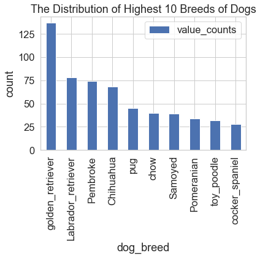

```python
dog_breed_value_counts.head(10).plot(kind='bar');
plt.title('The Distribution of Highest 10 Breeds of Dogs');
plt.ylabel('count');
plt.grid(True);
```

## The Distribution of Stages of Dogs

```python
stage_value_counts = df.stage.value_counts().to_frame()
stage_value_counts.rename(columns={'stage':'value_counts'},inplace=True)
stage_value_counts.index.name='stage'
stage_value_counts
```

| stage | value_counts |
| --- | --- |
| unclassified | 908 |
| pup | 346 |
| doggo | 41 |
| floofer | 5 |
| woof | 4 |

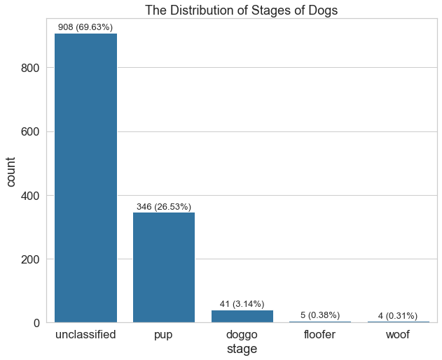

```python
category_plot(df, 'stage', 'The Distribution of Stages of Dogs')
```

## The Distribution of Prediction Algorithms

- #1 prediction algorithm got involved in about 88.04 % in predicting breeds of the dogs
- #2 prediction algorithm got involved in about 8.13 % in predicting breeds of the dogs
- #3 prediction algorithm got involved in about 3.83 % in predicting breeds of the dogs

```python
prediction_algorithm_value_counts = df.prediction_algorithm.value_counts().to_frame()
prediction_algorithm_value_counts.rename(columns={'prediction_algorithm':'value_counts'},inplace=True)
prediction_algorithm_value_counts.index.name='prediction_algorithm'
prediction_algorithm_value_counts
```

| prediction_algorithm | value_counts |
| --- | --- |
| P_1 | 1148 |
| P_2 | 106 |
| P_3 | 50 |

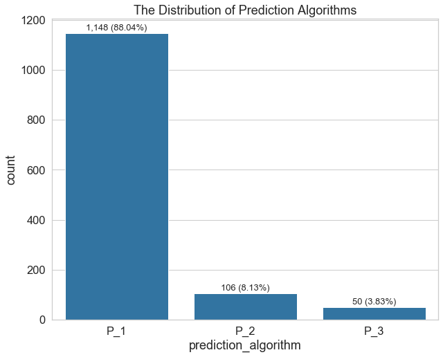

```python
category_plot(df, 'prediction_algorithm', 'The Distribution of Prediction Algorithms')
```

## The Distribution of Images Number

- about 83 % of image #1 are used in predicting breeds of dogs
- about 11.35 % of image #2 are used in predicting breeds of dogs
- about 4 % of image #3 are used in predicting breeds of dogs
- about 1.7 % of image #4 are used in predicting breeds of dogs

```python
img_num_value_counts = df.img_num.value_counts().to_frame()
img_num_value_counts.rename(columns={'img_num':'value_counts'},inplace=True)
img_num_value_counts.index.name='img_num'
img_num_value_counts
```

| img_num | value_counts |
| --- | --- |
| img_1 | 1082 |
| img_2 | 148 |
| img_3 | 52 |
| img_4 | 22 |

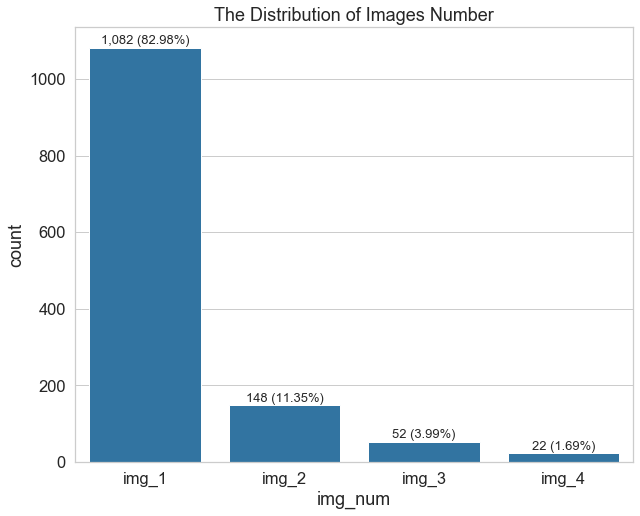

```python
category_plot(df, 'img_num', 'The Distribution of Images Number')
```

## The Distribution of Times of Day

- about `49.08 %` of tweets is posted at `Late Night`
  - about `20.78 %` of tweets is posted at `Evening`
  - about `16.64 %` of tweets is posted at `Afternoon`
  - about `12.58 %` of tweets is posted at `Night`
  - about `0.92 %` of tweets is posted at `Early Morning`
  - no tweet is posted at `Morning`

```python
time_of_day_value_counts = df.time_of_day.value_counts().to_frame()
time_of_day_value_counts.rename(columns={'time_of_day':'value_counts'},inplace=True)
time_of_day_value_counts.index.name='time_of_day'
time_of_day_value_counts
```

| time_of_day | value_counts |
| --- | --- |
| Late Night | 640 |
| Evening | 271 |
| afternoon | 217 |
| Night | 164 |
| Early Morning | 12 |
| Morning | 0 |

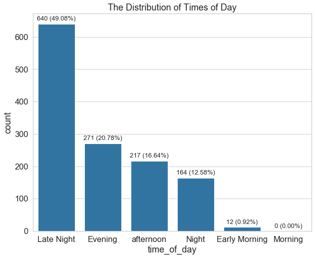

```python
category_plot(df, 'time_of_day', 'The Distribution of Times of Day')
```

## Retweet Count Distribution

- Distribution of Retweet Count is unimodal and symmetric, it has about the same shape on either side of the middle.

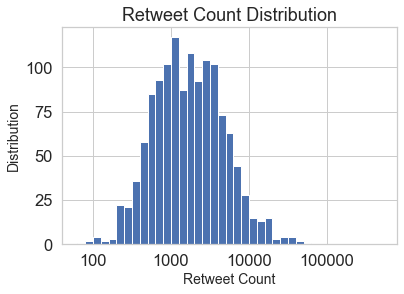

```python
bins_edge = 10**np.arange(1.8, np.log10(df.retweet_count.max())+1, 0.1)
plt.hist(data=df, x='retweet_count', bins=bins_edge);
ticks = [10**x for x in range(2,6)]
labels = ['{}'.format(x) for x in ticks]
plt.xscale('log');
plt.xticks(ticks, labels);
plt.xlabel('Retweet Count', fontsize=14);
plt.ylabel('Distribution', fontsize=14);
plt.title('Retweet Count Distribution');
plt.show();
```

## Favorite Count Distribution

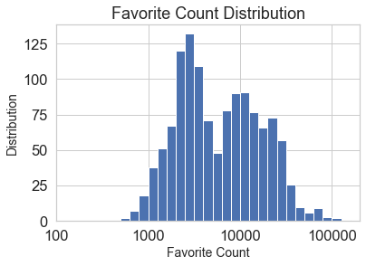

```python
bins_edge = 10**np.arange(2.7, np.log10(df.favorite_count.max())+1, 0.1)
plt.hist(data=df, x='favorite_count', bins=bins_edge); #favorite_count
plt.xscale('log');
ticks = [10**x for x in range(2,6)]
labels = ['{}'.format(x) for x in ticks]
plt.xscale('log');
plt.xlim(right=10**5+10**5);
plt.xticks(ticks, labels);
plt.xlabel('Favorite Count', fontsize=14);
plt.ylabel('Distribution', fontsize=14);
plt.title('Favorite Count Distribution');
plt.show();
```

## Rating Numerator Distribution

- Distribution of Rating is unimodal and skewed to left
- Rating is based on dog's owner not audience, so it won't be fair if we use rating variable to determine best dog rating. also, we shouldn't involve rating variable in bivariate exploration or multivariate exploration

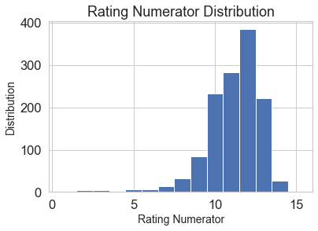

```python
bins_edge = np.arange(df.rating_numerator.min(), 14+1, 1)
plt.hist(data=df, x='rating_numerator', bins=bins_edge+0.5);
plt.xlim(right=16);
plt.xlabel('Rating Numerator', fontsize=14);
plt.ylabel('Distribution', fontsize=14);
plt.title('Rating Numerator Distribution');
```

## Average Confidance for Prediction Algorithms

#### from `The Distribution of Prediction Algorithms` and `Average Confidance for Prediction Algorithms` :

- #1 prediction algorithm got involved in about 88.04 % in predicting the most correct breed with average confidance about 62 %
- #2 prediction algorithm got involved in about 8.13 % in predicting the most correct breed with average confidance about 12 %
- #3 prediction algorithm got involved in about 3.83 % in predicting the most correct breed with average confidance about 5 %

```python
df.groupby(['prediction_algorithm'])[['algorithm_conf']].mean()
```

| prediction_algorithm | algorithm_conf |
| --- | --- |
| P_1 | 0.621783 |
| P_2 | 0.122478 |
| P_3 | 0.049857 |

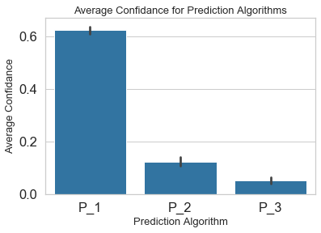

```python
sns.barplot(x='prediction_algorithm', y='algorithm_conf', data=df, color = 'tab:blue');
plt.xlabel('Prediction Algorithm', fontsize=13);
plt.ylabel('Average Confidance', fontsize=13);
plt.title('Average Confidance for Prediction Algorithms', fontsize=13);
```

## Average Confidance for Image Number

#### from `The Distribution of Images Number` and `Average Confidance for Image Number` :

- about 83 % of image #1 has average confidance about 54 %
- about 11.35 % of image #2 has average confidance about 63 %
- about 4 % of image #3 has average confidance about 62.5 %
- about 1.7 % of image #4 has average confidance about 83 %

```python
df.groupby(['img_num'])[['algorithm_conf']].mean()
```

| img_num | algorithm_conf |
| --- | --- |
| img_1 | 0.540728 |
| img_2 | 0.631417 |
| img_3 | 0.625300 |
| img_4 | 0.829510 |

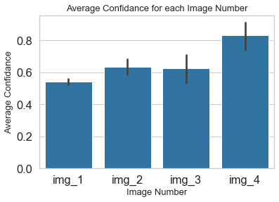

```python
sns.barplot(x='img_num', y='algorithm_conf', data=df, color = 'tab:blue');
plt.xlabel('Image Number', fontsize=13);
plt.ylabel('Average Confidance', fontsize=13);
plt.title('Average Confidance for each Image Number', fontsize=13);
```

## Prediction Algorithms and Image Number

- here, we will see the distribution of each prediction algorithm for each image
- the most used image in all algorithms is the first image (img_1)

```python
df.groupby(['img_num','prediction_algorithm'])[['prediction_algorithm']].count().fillna(0)
```

| img_num | prediction_algorithm | prediction_algorithm |
| --- | --- | --- |
| img_1 | P_1 | 952.0 |
|  | P_2 | 90.0 |
|  | P_3 | 40.0 |
| img_2 | P_1 | 132.0 |
|  | P_2 | 10.0 |
|  | P_3 | 6.0 |
| img_3 | P_1 | 43.0 |
|  | P_2 | 6.0 |
|  | P_3 | 3.0 |
| img_4 | P_1 | 21.0 |
|  | P_2 | 0.0 |
|  | P_3 | 1.0 |

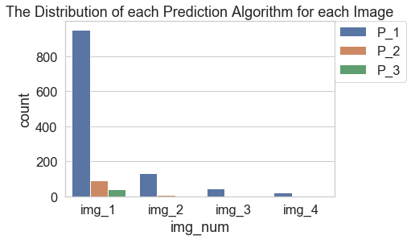

```python
sns.countplot(data = df, x = 'img_num', hue='prediction_algorithm', order=df.img_num.value_counts().index);
plt.legend(bbox_to_anchor=(1, 1), loc=2, borderaxespad=0.);
plt.title('The Distribution of each Prediction Algorithm for each Image');
```

### Relation between Retweet Count and Favorite Count:

- Retweet Count is proportional to Favorite Count as shown, and this confirms the positive correlation between these two variables

```python
df[['retweet_count','favorite_count']].corr()
```

|  | retweet_count | favorite_count |
| --- | --- | --- |
| retweet_count | 1.000000 | 0.846324 |
| favorite_count | 0.846324 | 1.000000 |

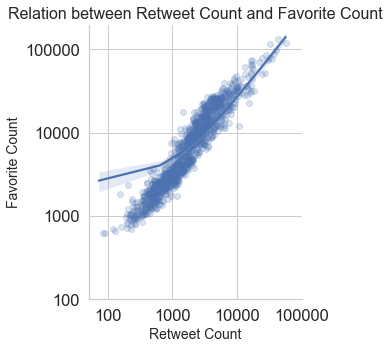

```python
sns.lmplot(x="retweet_count", y="favorite_count", data = df,scatter_kws = {'alpha':0.2});
plt.xscale('log');
plt.yscale('log');
xlocs = [10**x for x in range(2,6)]
xlabels = ['{}'.format(x) for x in ticks]
ylocs = [10**x for x in range(2,6)]
ylabels = ['{}'.format(x) for x in ticks]
plt.xticks(xlocs, xlabels);
plt.yticks(ylocs, ylabels);
plt.xlabel('Retweet Count', fontsize=14);
plt.ylabel('Favorite Count', fontsize=14);
plt.title('Relation between Retweet Count and Favorite Count', fontsize=16);
plt.show();
```

## Average Confidance corresponding to Prediction Algorithms and Image Number

```python
df.groupby(['img_num','prediction_algorithm'])[['algorithm_conf']].mean().fillna(0)
```

| img_num | prediction_algorithm | algorithm_conf |
| --- | --- | --- |
| img_1 | P_1 | 0.599751 |
|  | P_2 | 0.132459 |
|  | P_3 | 0.054584 |
| img_2 | P_1 | 0.702210 |
|  | P_2 | 0.056392 |
|  | P_3 | 0.032339 |
| img_3 | P_1 | 0.744472 |
|  | P_2 | 0.082903 |
|  | P_3 | 0.001966 |
| img_4 | P_1 | 0.863793 |
|  | P_2 | 0.000000 |
|  | P_3 | 0.109570 |

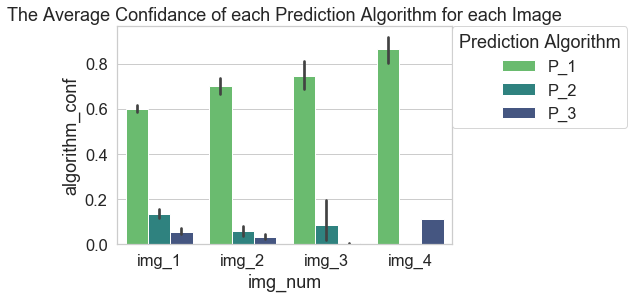

```python
sns.barplot(data = df, x='img_num' , y='algorithm_conf', hue='prediction_algorithm', palette = 'viridis_r',
            order=df.img_num.value_counts().index);
plt.legend(title = 'Prediction Algorithm',bbox_to_anchor=(1, 1), loc=2, borderaxespad=0.);
plt.title('The Average Confidance of each Prediction Algorithm for each Image');
```